# gperez_Assign8

Gera

9/13/2019

This is an exercise for KEGG Gene Set Enrichment Analysis and Visualization of RNA-Seq data

setwd(“/Users/gerardoperez/Documents/shell/Bi623/Assign8”)

```bash
scp /projects/bgmp/shared/Bi623/assign8/* .
```

1. Load the libraries gage, gageData, and pathview, and read in the edgeR differential gene expression results for pipefish

```r
library(gage)
library(gageData)
library(pathview)
# import file into R for analysis
kegg_pouch <- read.delim("pouch_RNAseq.tsv", sep = "\t",
                         stringsAsFactors=FALSE)

head(kegg_pouch)
```

```
##              gene     logFC   logCPM   PValue      FDR
## 1 SSCG00000006879 -4.773818 5.819960 7.91e-43 1.21e-38
## 2 SSCG00000018539 -3.628438 3.996378 2.04e-26 1.56e-22
## 3 SSCG00000006913  3.969190 2.852701 2.13e-24 8.13e-21
## 4 SSCG00000007973 -2.241212 5.737163 1.66e-24 8.13e-21
## 5 SSCG00000013585 -3.430436 4.255368 1.07e-23 3.26e-20
## 6 SSCG00000005985 -7.745400 9.349317 7.29e-23 1.85e-19
##                      blastp_hit_ID percent_ident aln_length mismatch_count
## 1      gi|808868665|gb|KKF18926.1|         48.33       2363            748
## 2      gi|564584365|gb|AHB86582.1|         66.67         54             18
## 3 gi|657527052|ref|XP_008286151.1|         67.62        349            104
## 4 gi|736248742|ref|XP_010787360.1|         87.27        589             44
## 5      gi|808866420|gb|KKF17125.1|         52.90       1121            407
## 6      gi|118344658|gb|ABK80841.1|         68.66        201             63
##   gap_open_count query_start query_end subject_start subject_end evalue
```

[output cut: 27 more lines]

2. Set up and perform GSEA for all KEGG pathways using gage

```r
#Loads the KEGG orthology data from the gageData database

data(kegg.sets.ko)
data(sigmet.idx.ko)
kegg.sets.ko <- kegg.sets.ko[sigmet.idx.ko]
head(kegg.sets.ko, 3)
```

```
## $`ko00970 Aminoacyl-tRNA biosynthesis`
##  [1] "K00604" "K01042" "K01866" "K01867" "K01868" "K01869" "K01870"
##  [8] "K01872" "K01873" "K01874" "K01875" "K01876" "K01878" "K01879"
## [15] "K01880" "K01881" "K01883" "K01884" "K01885" "K01886" "K01887"
## [22] "K01889" "K01890" "K01892" "K01893" "K02433" "K02434" "K02435"
## [29] "K03330" "K03341" "K04566" "K04567" "K04568" "K06868" "K07587"
## [36] "K09482" "K09698" "K09759" "K10837" "K11627" "K14163" "K14164"
## [43] "K14218" "K14219" "K14220" "K14221" "K14222" "K14223" "K14224"
## [50] "K14225" "K14226" "K14227" "K14228" "K14229" "K14230" "K14231"
## [57] "K14232" "K14233" "K14234" "K14235" "K14236" "K14237" "K14238"
## [64] "K14239"
##
## $`ko02010 ABC transporters`
##   [1] "K01995" "K01996" "K01997" "K01998" "K01999" "K02000" "K02001"
##   [8] "K02002" "K02006" "K02007" "K02008" "K02009" "K02010" "K02011"
```

[output cut: 116 more lines]

```r
class(kegg.sets.ko)
```

```
## [1] "list"
```

What class of object is kegg.sets.ko, and what kind of information does it contain?

**The class object for kegg.sets.ko is a list. It contains kegg pathway entries with its orthology.**

```r
#Constructs a vector of log2 fold change values and use the names() function to name each component with a ko ID
#Important: will allow to do GSEA for all of the KEGG pathways, based on log2 fold change, per-gene measure of differential expression.

pouch_foldchanges <- kegg_pouch$logFC
names(pouch_foldchanges) <- kegg_pouch$ko_ID
head(pouch_foldchanges)
```

```
##    K08867              K06827    K08621              K08076
## -4.773818 -3.628438  3.969190 -2.241212 -3.430436 -7.745400
```

```r
#Runs gage() on our vector of log2 fold change values to test, for each KEGG pathway, enrichment for genes with extreme values.

pouch_test <- gage(pouch_foldchanges, gsets=kegg.sets.ko,
                   same.dir=FALSE)

#Performs a “two-tailed” test, meaning a significantly enriched KEGG pathway can be defined by extreme fold changes in either direction.
#Uses lapply() on the head() function to look at the top entries of the two elements in our list

lapply(pouch_test, head)
```

```
## $greater
##                                                    p.geomean stat.mean
## ko04060 Cytokine-cytokine receptor interaction  0.0004157785  3.389309
## ko04080 Neuroactive ligand-receptor interaction 0.0005931042  3.291588
## ko04020 Calcium signaling pathway               0.0009541734  3.166149
## ko04610 Complement and coagulation cascades     0.0020856531  3.051847
## ko04151 PI3K-Akt signaling pathway              0.0044143052  2.634479
## ko04713 Circadian entrainment                   0.0051888668  2.642224
##                                                        p.val      q.val
## ko04060 Cytokine-cytokine receptor interaction  0.0004157785 0.05337938
## ko04080 Neuroactive ligand-receptor interaction 0.0005931042 0.05337938
## ko04020 Calcium signaling pathway               0.0009541734 0.05725040
## ko04610 Complement and coagulation cascades     0.0020856531 0.09385439
## ko04151 PI3K-Akt signaling pathway              0.0044143052 0.15225070
## ko04713 Circadian entrainment                   0.0051888668 0.15225070
##                                                 set.size         exp1
## ko04060 Cytokine-cytokine receptor interaction       110 0.0004157785
## ko04080 Neuroactive ligand-receptor interaction      118 0.0005931042
## ko04020 Calcium signaling pathway                     86 0.0009541734
## ko04610 Complement and coagulation cascades           27 0.0020856531
## ko04151 PI3K-Akt signaling pathway                   169 0.0044143052
## ko04713 Circadian entrainment                         46 0.0051888668
##
## $stats
##                                                 stat.mean     exp1
## ko04060 Cytokine-cytokine receptor interaction   3.389309 3.389309
## ko04080 Neuroactive ligand-receptor interaction  3.291588 3.291588
## ko04020 Calcium signaling pathway                3.166149 3.166149
## ko04610 Complement and coagulation cascades      3.051847 3.051847
## ko04151 PI3K-Akt signaling pathway               2.634479 2.634479
## ko04713 Circadian entrainment                    2.642224 2.642224
```

```r
head(pouch_test$greater, 30)
```

```
##                                                         p.geomean
## ko04060 Cytokine-cytokine receptor interaction       0.0004157785
## ko04080 Neuroactive ligand-receptor interaction      0.0005931042
## ko04020 Calcium signaling pathway                    0.0009541734
## ko04610 Complement and coagulation cascades          0.0020856531
## ko04151 PI3K-Akt signaling pathway                   0.0044143052
## ko04713 Circadian entrainment                        0.0051888668
## ko04970 Salivary secretion                           0.0061898313
## ko04270 Vascular smooth muscle contraction           0.0069808347
## ko04630 Jak-STAT signaling pathway                   0.0076125348
## ko04640 Hematopoietic cell lineage                   0.0098548132
## ko04510 Focal adhesion                               0.0103597436
## ko04360 Axon guidance                                0.0122278224
## ko04514 Cell adhesion molecules (CAMs)               0.0175389731
## ko00830 Retinol metabolism                           0.0179790150
## ko04974 Protein digestion and absorption             0.0186986476
## ko04730 Long-term depression                         0.0244453815
## ko04512 ECM-receptor interaction                     0.0259167533
## ko04390 Hippo signaling pathway                      0.0274056013
## ko04540 Gap junction                                 0.0288001271
## ko04010 MAPK signaling pathway                       0.0293391813
## ko04724 Glutamatergic synapse                        0.0306219812
## ko04340 Hedgehog signaling pathway                   0.0322508034
## ko04723 Retrograde endocannabinoid signaling         0.0389473917
## ko04973 Carbohydrate digestion and absorption        0.0396414725
## ko04911 Insulin secretion                            0.0402522048
## ko04917 Prolactin signaling pathway                  0.0465133280
## ko00980 Metabolism of xenobiotics by cytochrome P450 0.0536196854
## ko04725 Cholinergic synapse                          0.0572099279
## ko04062 Chemokine signaling pathway                  0.0652124119
## ko04916 Melanogenesis                                0.0717248829
##                                                      stat.mean
## ko04060 Cytokine-cytokine receptor interaction        3.389309
## ko04080 Neuroactive ligand-receptor interaction       3.291588
## ko04020 Calcium signaling pathway                     3.166149
## ko04610 Complement and coagulation cascades           3.051847
## ko04151 PI3K-Akt signaling pathway                    2.634479
## ko04713 Circadian entrainment                         2.642224
## ko04970 Salivary secretion                            2.577435
## ko04270 Vascular smooth muscle contraction            2.493080
```

[output cut: 100 more lines]

```
## ko04730 Long-term depression                         0.0244453815
## ko04512 ECM-receptor interaction                     0.0259167533
## ko04390 Hippo signaling pathway                      0.0274056013
## ko04540 Gap junction                                 0.0288001271
## ko04010 MAPK signaling pathway                       0.0293391813
## ko04724 Glutamatergic synapse                        0.0306219812
## ko04340 Hedgehog signaling pathway                   0.0322508034
## ko04723 Retrograde endocannabinoid signaling         0.0389473917
## ko04973 Carbohydrate digestion and absorption        0.0396414725
## ko04911 Insulin secretion                            0.0402522048
## ko04917 Prolactin signaling pathway                  0.0465133280
## ko00980 Metabolism of xenobiotics by cytochrome P450 0.0536196854
## ko04725 Cholinergic synapse                          0.0572099279
## ko04062 Chemokine signaling pathway                  0.0652124119
## ko04916 Melanogenesis                                0.0717248829
```

```r
#Returns only those pathways such that our false discovery rate (FDR) is controlled at 0.1
pouch_test_FDR_0.1<-subset(pouch_test$greater, pouch_test$greater[,4]<0.1)
```

Which KEGG pathways are enriched for genes with exceptional pregnancy-specific gene expression?

**ko04060 Cytokine-cytokine receptor interaction**

**ko04080 Neuroactive ligand-receptor interaction**

**ko04020 Calcium signaling pathway**

**ko04610 Complement and coagulation cascades**

Which two of these are related to the immune system?

**ko04060 Cytokine-cytokine receptor interaction**

**ko04610 Complement and coagulation cascades**

3. Visualize pregnancy fold change magnitudes for all genes in the “coagulation and complement” KEGG pathway

```r
# Gets the  pathway and its ko ID from the gage() output by simple indexing and the substr() function.

pouch_pathways <- rownames(pouch_test$greater)[4]
pouch_ids <- substr(pouch_pathways, start=1, stop=7)
pouch_ids
```

```
## [1] "ko04610"
```

```r
#Draws the pathway with a color scale that reflects log2 fold change for each gene.

#The pathview() function will write 3 files to your working directory. “ko04610.pathview.png” is the one you want to have a look at.

pathview(gene.data=pouch_foldchanges,
         pathway.id=pouch_ids, species="ko", new.signature=FALSE,
         trans.fun = list(gene = NULL, cpd = NULL),
         low = list(gene = "green", cpd = "blue"),
         mid = list(gene = "yellow", cpd = "gray"),
         high = list(gene = "red", cpd = "yellow"), na.col = "transparent")
```

```
## Note: Only KEGG ortholog gene ID is supported, make sure it looks like "K01488"!
```

```
## Note: Mapping via KEGG gene ID (not Entrez) is supported for this species,
## it looks like "K01488"!
```

```
## Info: Working in directory /Users/gerardoperez/Documents/shell/Bi623/Assign8
```

```
## Info: Writing image file ko04610.pathview.png
```

4. Visualize multi-genic expression patterns in pregnant and non-pregnant pouch tissues using non-metric multidimensional scaling

```r
library(vegan)
library(MASS)
# import file into R for analysis
pipe_TMMvals <- read.csv("pouch_TMM_values.csv", head = TRUE,
                           row.names = 1)
dim(pipe_TMMvals)
```

```
## [1] 15253    12
```

```r
pipe_TMMvals <- t(pipe_TMMvals)
#head(pipe_TMMvals)
```

What happened to our data frame after using the t() function?

**The data went from 15253 observations of 12 variables to a large matrix of 183036 elements that outputs the first column of the original data frame after executing it with the head function. It made the matrix transpose and made the rows into columns suggesting that this is the transpose function**

```r
#Computes a dissimilarity matrix (distances between pipefish samples in “transcript space”) using the default for vegdist(), which is a metric called Bray-Curtis dissimilarity.

pipe.dis <- vegdist(pipe_TMMvals)
```

What do you think is meant by “convergence”? Think about how nmds works, and consult the literature, if necessary.

**A best fit that has minimum stress levels for both axis. Reducing the stress levels of distances 15,252 dimensions into 2 dimensions by distances.**

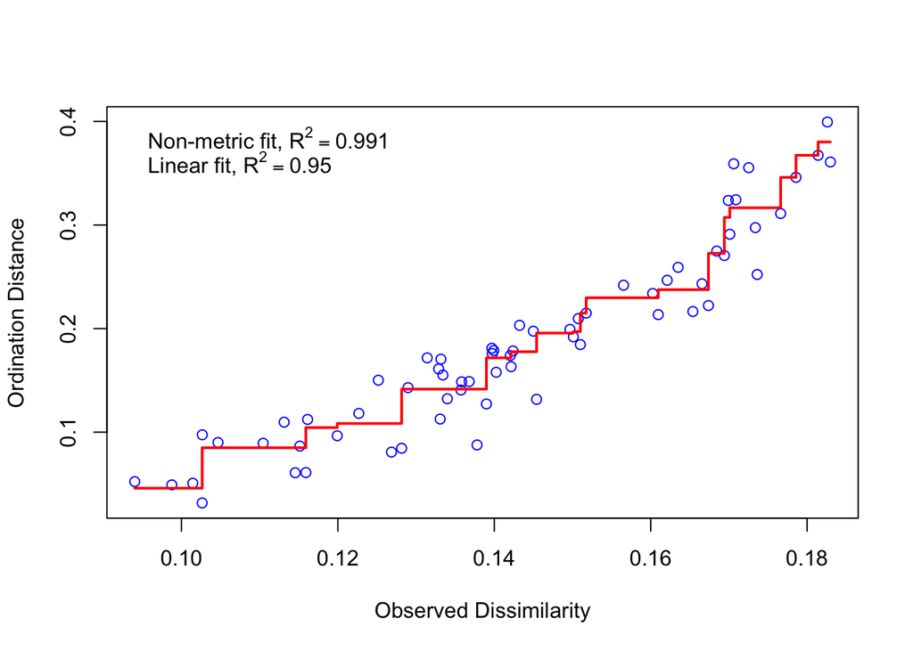

```r
# Fits of the new, 2-D distances to the original, 15,252-D distances
# Visualizes a stress plot (or Shepard plot), which plots the 2-D versus 15,252-D distance ranks.

pipe.mds0 <- isoMDS(pipe.dis, k=2)
stressplot(pipe.mds0, pipe.dis)
```

```r
# constructs a data frame that links the pouch sample IDs with pregnancy status.

Targets <- as.data.frame(rownames(pipe_TMMvals))
Targets$PregStat <- factor(c(rep("preg",6),rep("nonpreg",6)))
colnames(Targets) <- c("ID","PregStat")

#Defines the ordination plotting parameters
# ordiplot() function will produce an empty space

par(mgp = c(2.5, 1, 0))
preg=as.character(Targets$PregStat)

fig <- ordiplot(pipe.mds0, main="Brood Pouches in Transcript Space",
                ylab="nMDS Dimension 2", xlab="nMDS Dimension 1",
                font.lab=2, font.axis=2, cex.axis=.7, type="none", cex.main=1,
                xlim=(c(-.2,0.2)))
```

```
## species scores not available
```

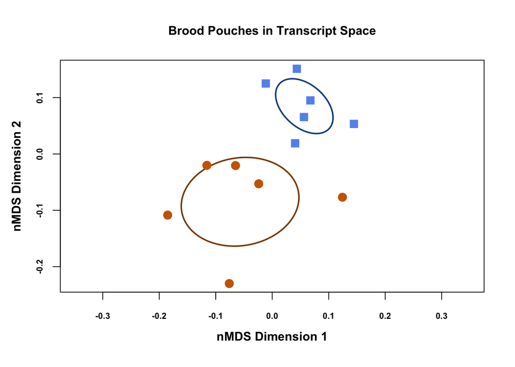

```r
#Adds “confidence ellipses” and the individual samples as points using the ordiellipse() and points() functions

ordiellipse(pipe.mds0,groups=preg,label=FALSE, lwd=2,
              show.groups=preg[1:6], col="darkorange4",
            draw="lines")
ordiellipse(pipe.mds0,groups=preg,label=FALSE, lwd=2,
              show.groups=preg[7:12], col="dodgerblue4",
            draw="lines")

points(fig, "sites", pch=c(rep(19,6),rep(15,6)),
         col=c(rep("darkorange3",6),rep("cornflowerblue",6)), cex=1.5)
```

What does this plot tell you about the brood pouch transcriptomes profiled in this study?

**Transcriptiome clusters separately by pregnancy status. Also there is more Beta diversity in pregnant males compared to non-pregnant males.**

```r
#Repeats the ordination (starting with the isoMDS() call), but this time generates 3 nMDS dimensions as opposed to 2.

pipe.mds1 <- isoMDS(pipe.dis, k=3)
```

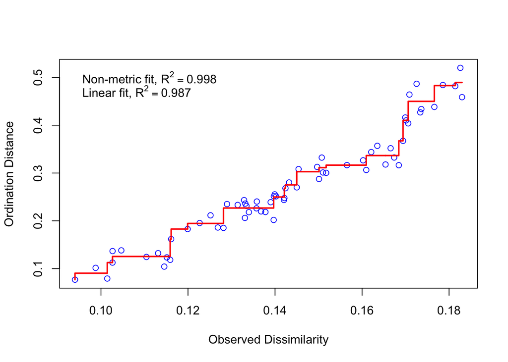

```r
stressplot(pipe.mds1, pipe.dis)
```

```r
Targets <- as.data.frame(rownames(pipe_TMMvals))
Targets$PregStat <- factor(c(rep("preg",6),rep("nonpreg",6)))
colnames(Targets) <- c("ID","PregStat")

par(mgp = c(2.5, 1, 0))
preg=as.character(Targets$PregStat)

#head(pipe.mds1$points)

fig2 <- ordiplot(pipe.mds1$points[,2:3], main="Brood Pouches in Transcript Space",
                ylab="nMDS Dimension 3", xlab="nMDS Dimension 2",
                font.lab=2, font.axis=2, cex.axis=.7, type="none", cex.main=1,
                xlim=(c(-.2,0.2)))
```

```
## species scores not available
```

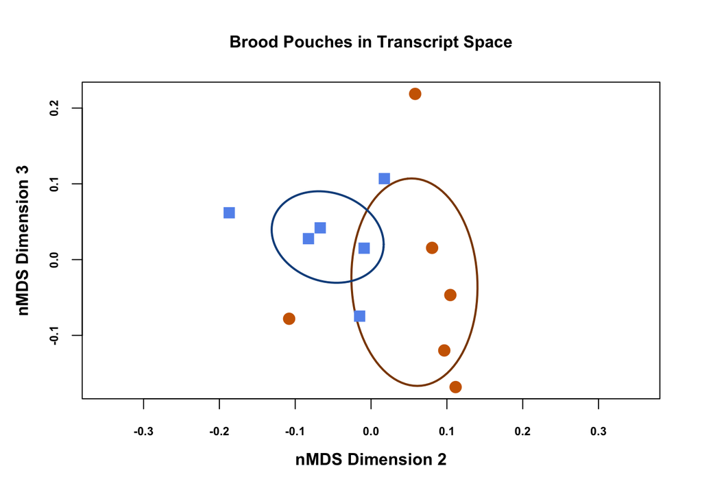

```r
ordiellipse(pipe.mds1$points[,2:3],groups=preg,label=FALSE, lwd=2,
            show.groups=preg[1:6], col="darkorange4",
            draw="lines")
ordiellipse(pipe.mds1$points[,2:3],groups=preg,label=FALSE, lwd=2,
            show.groups=preg[7:12], col="dodgerblue4",
            draw="lines")

points(fig2, "sites", pch=c(rep(19,6),rep(15,6)),
       col=c(rep("darkorange3",6),rep("cornflowerblue",6)), cex=1.5)
```

5.Permutational Multivariate Analysis of Variance (perMANOVA) to test for multivariate transcriptional differences between pregnant and non-pregnant males

```r
#Defines a dataframe with Targets data frame to execute the adonis() function, which runs the perMANOVA,

otu.env <- Targets
adonis(pipe.dis ~ PregStat, otu.env, perm=999)
```

```
##
## Call:
## adonis(formula = pipe.dis ~ PregStat, data = otu.env, permutations = 999)
##
## Permutation: free
## Number of permutations: 999
##
## Terms added sequentially (first to last)
##
##           Df SumsOfSqs   MeanSqs F.Model      R2 Pr(>F)
## PregStat   1  0.030265 0.0302654   3.548 0.26188  0.002 **
## Residuals 10  0.085304 0.0085304         0.73812
## Total     11  0.115569                   1.00000
## ---
## Signif. codes:  0 '***' 0.001 '**' 0.01 '*' 0.05 '.' 0.1 ' ' 1
```

6. Constructing a heatmap with clustering dendrograms for Coagulation and Complement Cascade KEGG pathway genes.

```r
library(gplots)
library(RColorBrewer)
library(dendextend)
# import file into R for analysis
pouch_compcoag <- read.delim("CompCoag_pouch_multivar.tsv", sep = "\t",
                             row.names = 1, header = F)

colnames(pouch_compcoag)<- c("KO","name","P9","P8","P7","P6","P5","P3",
                                        "NP11","NP10","NP4","NP3","NP2","NP1")

#Defines a vector for gene names
names_compcoag <- pouch_compcoag$name

#Defines a new data frame consisting of just the CPM columns and call it “pouch_compcoag”, but log-transform (base 2) each CPM value + 0.01.
pouch_compcoag<-log2(pouch_compcoag[,3:14]+0.01)
```

Why do we add 0.01 to all values?

**We add 0.01 in case if a value is close to or at zero due to log of 0 not being defined.**

transpose for row-wise scaling.

```r
# Transposes for row-wise scaling.
pouch_compcoag.n <- scale(t(pouch_compcoag))

#Put data back in original orientation
pouch_compcoag.tn <- t(pouch_compcoag.n)

class(pouch_compcoag.tn )
```

```
## [1] "matrix"
```

What class of object are we dealing with now?

**The class of object we are dealing now is a matrix**

```r
#Calculates multivariate dissimilarity for all sample pairs, using Euclidean Distance
compcoag.d1 <- dist(pouch_compcoag.n, method = "euclidean", diag = FALSE,
                    upper = FALSE)

# Looks at the distances
round(compcoag.d1,3)
```

```
##          P9     P8     P7     P6     P5     P3   NP11   NP10    NP4    NP3
## P8    7.201
## P7    6.287  6.845
## P6    7.346  9.026  7.715
## P5    8.339  9.221  8.325 10.001
## P3    7.746 10.399  9.492  8.152 10.093
## NP11  8.452  8.027  7.640  9.258  9.043 10.887
## NP10  9.667  8.717  9.411 10.335  9.606  9.625  7.844
## NP4   8.762  8.506  9.336 11.089  8.809 10.657  7.474  7.772
## NP3   8.273  7.805  8.380 10.431  9.599 11.282  7.043 10.073  7.945
## NP2   8.280  7.623  7.393  8.348  9.093  9.794  6.432  6.744  8.066  8.638
## NP1   9.709  8.244  8.768 10.442  9.181 11.779  7.764  9.086  7.520  8.879
##         NP2
## P8
## P7
## P6
## P5
## P3
## NP11
## NP10
## NP4
## NP3
## NP2
## NP1   7.654
```

Which two samples are the most dissimilar based on Euclidean Distance?

**The two samples most dissimilar are NP1 and P3.**

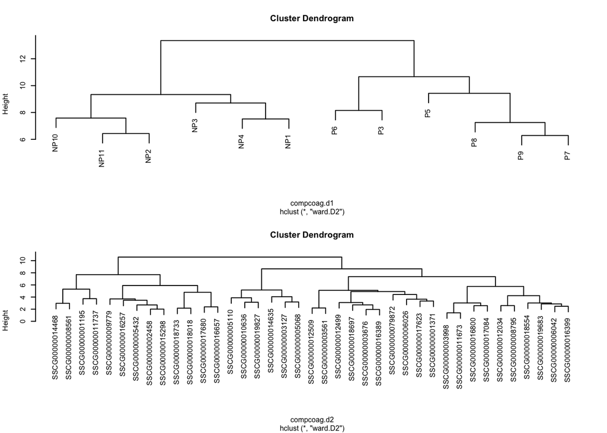

```r
#Calculates multivariate dissimilarity for all gene pairs
compcoag.d2 <- dist(pouch_compcoag.tn,method = "euclidean", diag = FALSE,
                              upper = TRUE)


#Using Ward linkage clustering, cluster samples, then gene
compcoag.c1 <- hclust(compcoag.d1, method = "ward.D2", members = NULL)
compcoag.c2 <- hclust(compcoag.d2, method = "ward.D2", members = NULL)

# Creates a plot with certain parameters.
par(mfrow=c(2,1),cex=0.5) # Make 2 rows, 1 col plot frame and shrink labels
plot(compcoag.c1)
plot(compcoag.c2)
```

```r
#Prints the order of samples (left to right) in the tree,
compcoag.c1$order
```

```
##  [1]  8  7 11 10  9 12  4  6  5  2  1  3
```

```r
#Sets the color scale for the heatmap. 299 increments is plenty of resolution!
compcoag_pal <- colorRampPalette(c("green","yellow","red"))
                                (n = 299)
```

```
## [1] 299
```

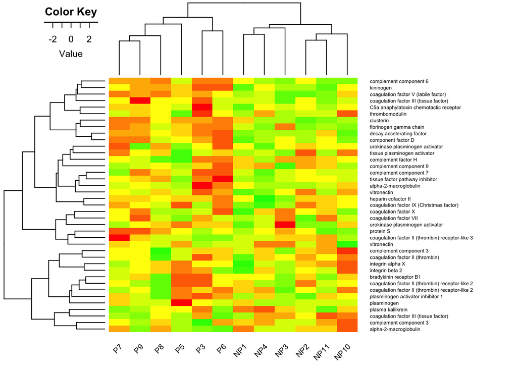

```r
#Plots the heatmap with heatmap.2 par(cex.main=0.5, cex.axis=0.5, font=2, font.axis=2) # Shrink title fonts on plot

heatmap.2(pouch_compcoag.tn,
          Colv=rotate(as.dendrogram(compcoag.c1),
          order=c(12,11,10,9,8,7,6,5,4,3,2,1)),
          Rowv=as.dendrogram(compcoag.c2),
          labRow=names_compcoag,
          density.info="none",
          trace="none",
          scale="none",
          col = compcoag_pal,
          cexRow=0.5,cexCol=0.75,
          margins=c(3,13), lwid=c(.8,3), lhei=c(.8,3),
          srtCol=45, adjCol=c(1,1),
          keysize=1.3)
```

Are there any groups of genes that differentiate between pregnant and non-pregnant males particularly well? If so, name those genes.

**Yes, the genes that differentiate between pregnant and non-pregnant males particularly well are complement component 6, kinogen, decay accelearating factor and component factor D.**

Repeat everything above

```r
# import file into R for analysis
pouch_compcoag_no_scale <- read.delim("CompCoag_pouch_multivar.tsv", sep = "\t",
                            row.names = 1, header = F)

colnames(pouch_compcoag_no_scale) <- c("KO","name","P9","P8","P7","P6","P5","P3",
                             "NP11","NP10","NP4","NP3","NP2","NP1")

#Defines a vector for gene names
names_compcoag <- pouch_compcoag_no_scale$name

#Defines a new data frame consisting of just the CPM columns, but log-transform (base 2) each CPM value + 0.01.
pouch_compcoag_no_scale<-log2(pouch_compcoag_no_scale[,3:14]+0.01)

# Transposes for row-wise
pouch_compcoag_no_scale.n <- t(pouch_compcoag_no_scale)

#Put data back in original orientation
pouch_compcoag_no_scale.tn <- t(pouch_compcoag_no_scale.n)

class(pouch_compcoag_no_scale.tn)
```

```
## [1] "matrix"
```

```r
#Calculates multivariate dissimilarity for all sample pairs, using Euclidean Distance
compcoag.d1_no_scale <- dist(pouch_compcoag_no_scale.n, method = "euclidean", diag = FALSE,
                   upper = FALSE)

# Looks at the distances
round(compcoag.d1_no_scale,3)
```

```
##          P9     P8     P7     P6     P5     P3   NP11   NP10    NP4    NP3
## P8    9.062
## P7    6.721  9.423
## P6    6.142 11.271  9.383
## P5    7.776  9.663  7.991 10.300
## P3    6.507 11.775  9.784  5.203 10.435
## NP11  7.969 12.267  7.881  9.652  8.737 10.539
## NP10  9.652 13.895  9.629 10.778 10.584 10.313  6.814
## NP4   8.647 11.144  9.037 11.259  8.352 11.046  6.886  8.439
## NP3   8.258  9.414  9.195 10.669  8.969 10.977  7.552 11.065  8.033
## NP2   7.523 11.003  7.931  7.892  9.498  9.179  5.538  7.081  8.225  8.213
## NP1   8.178  9.250  8.073  9.953  8.373 10.861  6.351  8.987  6.609  7.327
##         NP2
## P8
## P7
## P6
## P5
## P3
## NP11
## NP10
## NP4
## NP3
## NP2
## NP1   6.702
```

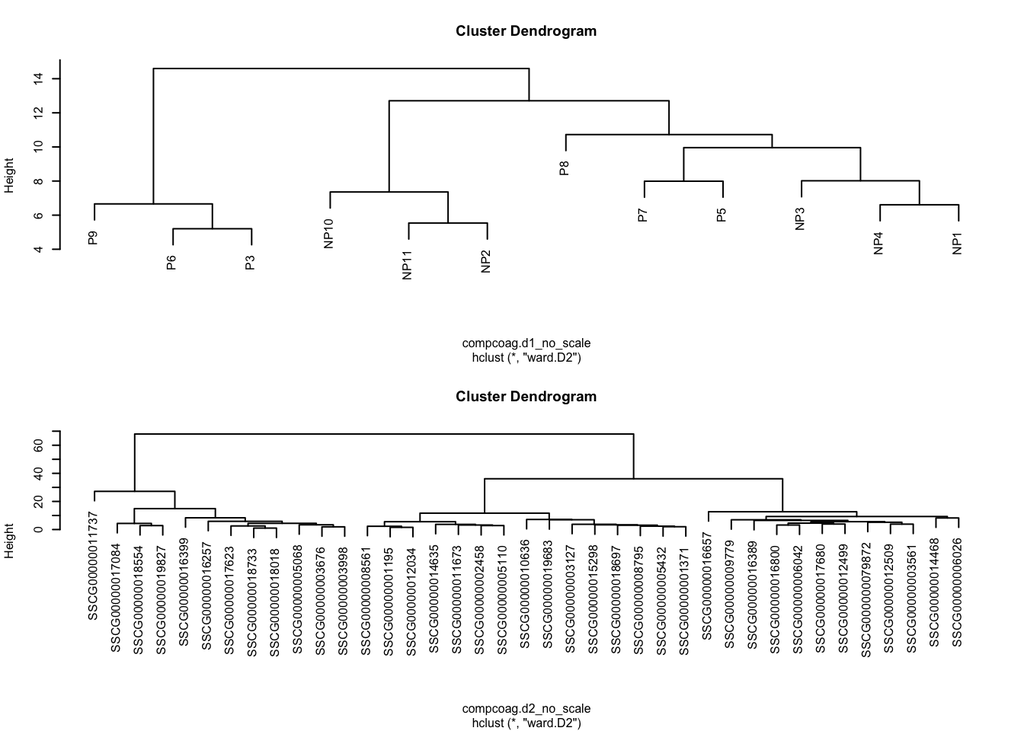

```r
#Calculates multivariate dissimilarity for all gene pairs
compcoag.d2_no_scale <- dist(pouch_compcoag_no_scale.tn,method = "euclidean", diag = FALSE,
                   upper = TRUE)

#Using Ward linkage clustering, cluster samples, then gene
compcoag.c1_no_scale <- hclust(compcoag.d1_no_scale, method = "ward.D2", members = NULL)
compcoag.c2_no_scale <- hclust(compcoag.d2_no_scale, method = "ward.D2", members = NULL)

# Creates a plot with certain parameters
par(mfrow=c(2,1),cex=0.5) # Make 2 rows, 1 col plot frame and shrink labels
plot(compcoag.c1_no_scale)
plot(compcoag.c2_no_scale)
```

```r
#Prints the order of samples (left to right) in the tree
compcoag.c1_no_scale$order
```

```
##  [1]  1  4  6  8  7 11  2  3  5 10  9 12
```

```r
#Sets the color scale for the heatmap. 299 increments is plenty of resolution!
compcoag_pal <- colorRampPalette(c("green","yellow","red"))
(n = 299)
```

```
## [1] 299
```

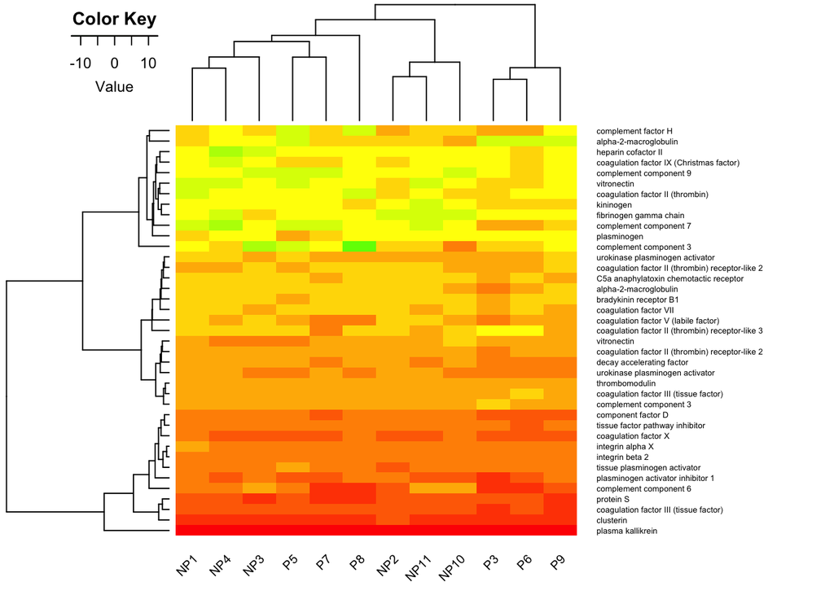

```r
#Plots the heatmap with heatmap.2 par(cex.main=0.5, cex.axis=0.5, font=2, font.axis=2) # Shrink title fonts on plot
heatmap.2(pouch_compcoag_no_scale.tn,
         Colv=rotate(as.dendrogram(compcoag.c1_no_scale),
                     order=c(12,11,10,9,8,7,6,5,4,3,2,1)),
         Rowv=as.dendrogram(compcoag.c2_no_scale),
         labRow=names_compcoag,
         density.info="none",
         trace="none",
         scale="none",
         col = compcoag_pal,
         cexRow=0.5,cexCol=0.75,
         margins=c(3,13), lwid=c(.8,3), lhei=c(.8,3),
         srtCol=45, adjCol=c(1,1),
         keysize=1.3)
```

Does your heatmap look any different? If so, explain why this might be.

**The heatmap looks different. There seems to be more upregulated expression, extreme values, throughout the heat map and there is no particularly well differentiation between pregnant and non-pregnant males. The scaling might have an effect on the graphic output by scaling such that the color choice is improved, so the color choice would not be dominated by the extreme values Also, this could be because not having the scale function increases the stress values.**

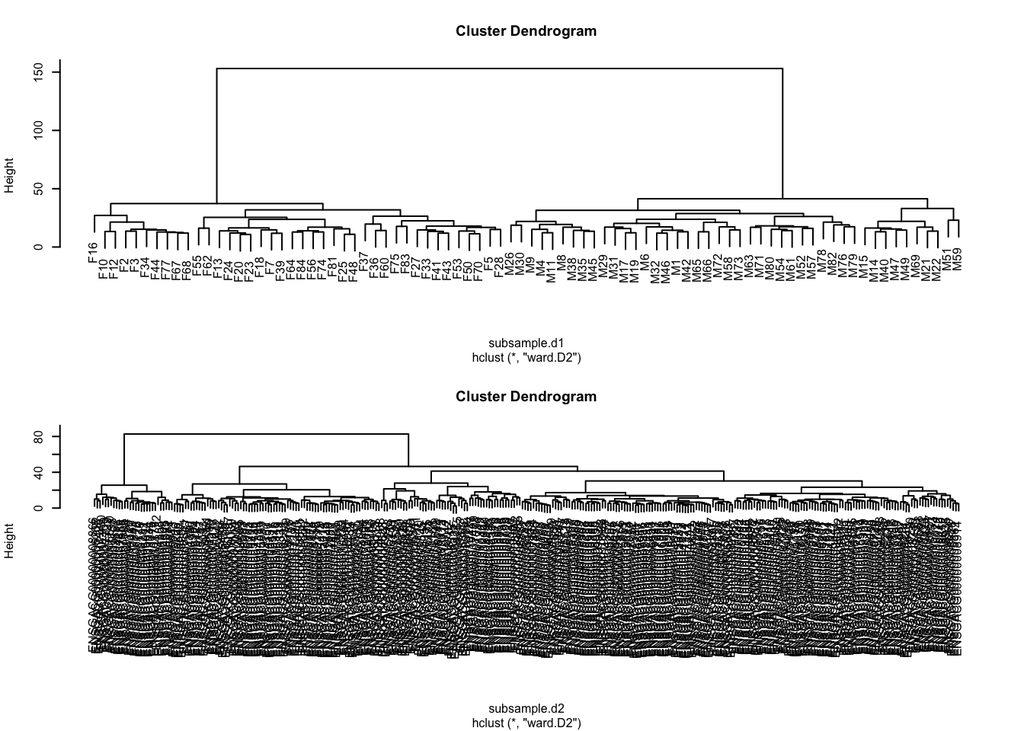

```r
# import file into R for analysis
subsample <- read.delim("stickleback_CPM.tsv", sep = "\t",
                             row.names = 1, header = T)

#subsets only genes that have the Genome_Loc value “groupXIX” AND have a Gene_Start_Pos value between 6000000 and 12000000.
subsample<-subset(subsample, subsample$Genome_Loc=="groupXIX" & subsample$Gene_Start_Pos>6000000 & subsample$Gene_Start_Pos<12000000)

#Defines a new data frame consisting of just the CPM column, but log-transform (base 2) each CPM value + 0.01.
stickle_CPM<-log2(subsample[,3:length(colnames(subsample))]+0.01)

# Transposes for row-wise scaling.
subsample.n<-scale(t(stickle_CPM))

#Put data back in original orientation
subsample.tn <- t(subsample.n)

#Calculates multivariate dissimilarity for all sample pairs, using Euclidean Distance
subsample.d1 <- dist(subsample.n, method = "euclidean", diag = FALSE,
                    upper = FALSE)
# Looks at the distances
#round(subsample.d1,3)

#Calculates multivariate dissimilarity for all gene pairs
subsample.d2 <- dist(subsample.tn,method = "euclidean", diag = FALSE,
                    upper = TRUE)

#Using Ward linkage clustering, cluster samples, then gene
subsample.c1 <- hclust(subsample.d1, method = "ward.D2", members = NULL)
subsample.c2 <- hclust(subsample.d2, method = "ward.D2", members = NULL)

# Creates a plot with certain parameters.
par(mfrow=c(2,1),cex=0.5) # Make 2 rows, 1 col plot frame and shrink labels
plot(subsample.c1)
plot(subsample.c2)
```

```r
#Prints the order of samples (left to right) in the tree
subsample.c1$order
```

```
##  [1] 16 10 12  2  3 34 44 77 67 68 55 62 13 24 20 23 18  7 39 64 84 56 74
## [24] 81 25 48 37 36 60 75 83 27 33 41 43 53 50 70  5 28 26 30  9  4 11  8
## [47] 38 35 45 29 31 17 19  6 32 46  1 42 65 66 72 58 73 63 71 80 54 61 52
## [70] 57 78 82 76 79 15 14 40 47 49 69 21 22 51 59
```

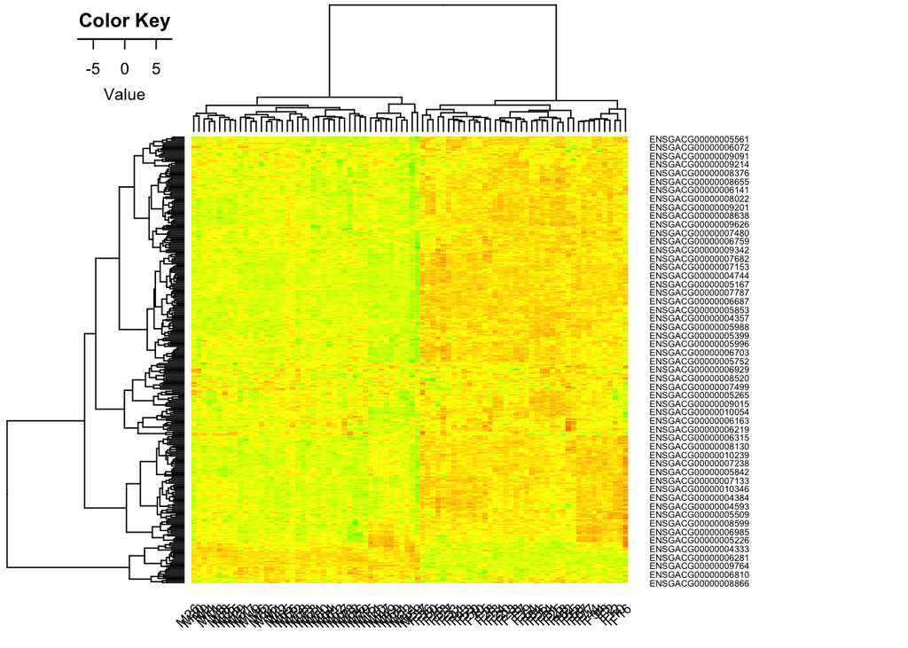

```r
#Sets the color scale for the heatmap. 299 increments is plenty of resolution!
subsample_pal <- colorRampPalette(c("green","yellow","red"))(n = 299)

#Plots the heatmap with heatmap.2 par(cex.main=0.5, cex.axis=0.5, font=2, font.axis=2) # Shrink title fonts on plot
heatmap.2(subsample.tn,
          Colv=rotate(as.dendrogram(subsample.c1 ),
                      order=c(12,11,10,9,8,7,6,5,4,3,2,1)),
          Rowv=as.dendrogram(subsample.c2),
          #labRow=names_subsample,
          density.info="none",
          trace="none",
          scale="none",
          col = subsample_pal,
          cexRow=0.5,cexCol=0.75,
          margins=c(3,13), lwid=c(.8,3), lhei=c(.8,3),
          srtCol=45, adjCol=c(1,1),
          keysize=1.3)
```

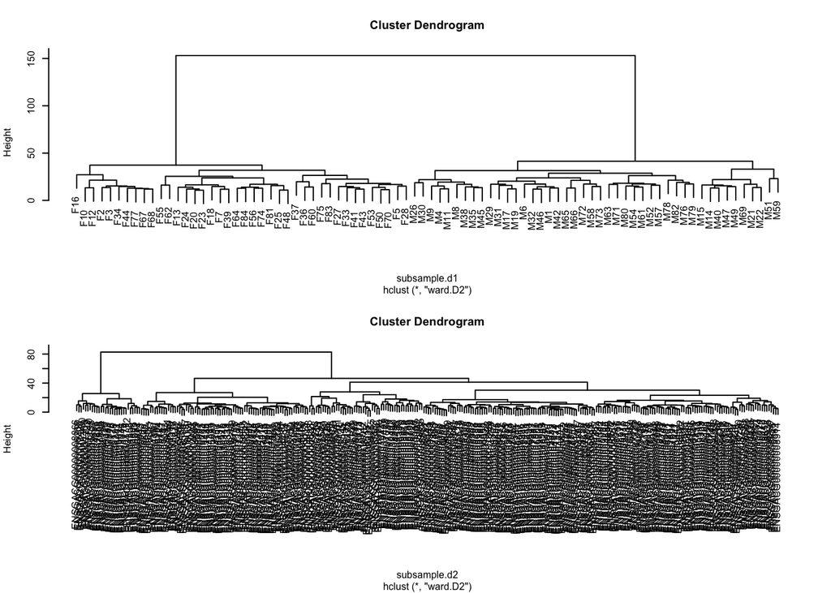

```r
# import file into R for analysis
subsample <- read.delim("stickleback_CPM.tsv", sep = "\t",
                        row.names = 1, header = T)


#Defines a new data frame consisting of just the CPM columns, but log-transform (base 2) each CPM value + 0.01.
stickle_CPM<-log2(subsample[,3:length(colnames(subsample))]+0.01)

#Takes a random sample of genes the same size as your first subset.
subsample2 <- stickle_CPM[sample(nrow(stickle_CPM),314),]

# Transposes for row-wise scaling.
subsample2.n<-scale(t(subsample2))

#Put data back in original orientation
subsample2.tn <- t(subsample2.n)

#Calculates multivariate dissimilarity for all sample pairs, using Euclidean Distance
subsample2.d1 <- dist(subsample2.n, method = "euclidean", diag = FALSE,
                     upper = FALSE)
# Looks at the distances
#round(subsample2.d1,3)

#Calculates multivariate dissimilarity for all gene pairs
subsample2.d2 <- dist(subsample2.tn,method = "euclidean", diag = FALSE,
                     upper = TRUE)

#Using Ward linkage clustering, cluster samples, then gene
subsample2.c1 <- hclust(subsample2.d1, method = "ward.D2", members = NULL)
subsample2.c2 <- hclust(subsample2.d2, method = "ward.D2", members = NULL)


# Creates a plot with certain parameters.
par(mfrow=c(2,1),cex=0.5) # Make 2 rows, 1 col plot frame and shrink labels
plot(subsample.c1)
plot(subsample.c2)
```

```r
#Prints the order of samples (left to right) in the tree
subsample2.c1$order
```

```
##  [1] 75 78 83 82 76 79 81 74 84 63 51 69 77 64 67 71 52 73 80 58 61 66 54
## [24] 57 53 68 50 70 59 72 56 65 55 62 16 30 40 47 49 14 15 19 17 20 21 22
## [47] 44 27 29 33 34 31 41 43 13 23 24  2 46 25 48 42  1 32  7  3 18 39 26
## [70] 28 37 36 60  8 35 45  9 38  5  6 12  4 10 11
```

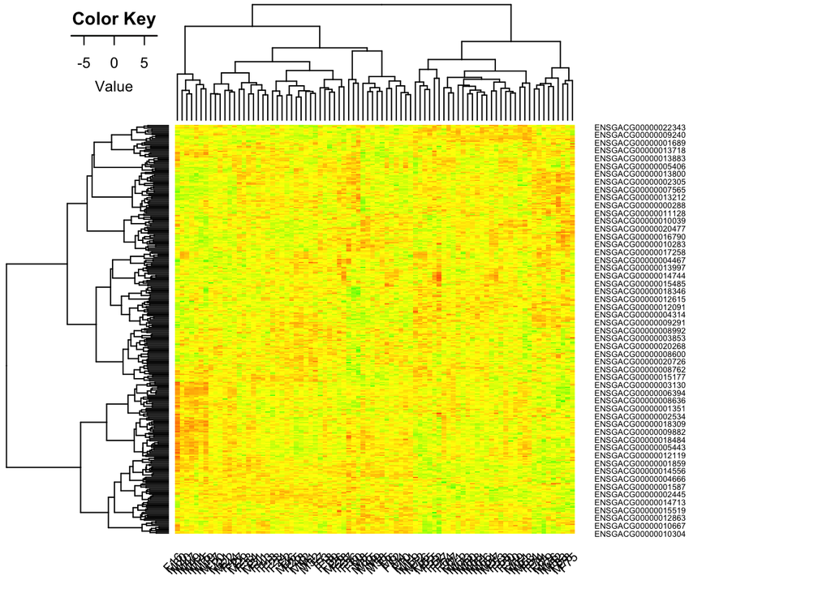

```r
#Sets the color scale for the heatmap. 299 increments is plenty of resolution!
subsample2_pal <- colorRampPalette(c("green","yellow","red"))(n = 299)

#Plots the heatmap with heatmap.2 par(cex.main=0.5, cex.axis=0.5, font=2, font.axis=2) # Shrink title fonts on plot
heatmap.2(subsample2.tn,
          Colv=rotate(as.dendrogram(subsample2.c1 ),
                      order=c(12,11,10,9,8,7,6,5,4,3,2,1)),
          Rowv=as.dendrogram(subsample2.c2),
          #labRow=names_subsample,
          density.info="none",
          trace="none",
          scale="none",
          col = subsample2_pal,
          cexRow=0.5,cexCol=0.75,
          margins=c(3,13), lwid=c(.8,3), lhei=c(.8,3),
          srtCol=45, adjCol=c(1,1),
          keysize=1.3)
```

Do you notice anything different about the clustering patterns for males and females between the two subsets? Do a quick literature search to find out why we might expect a difference given the biology of stickleback chromosome 19, and interpret what may be going on, especially regarding the clusters of genes that yield different sex-specific expression patterns in the groupXIX heatmap.

**There was a difference, the first heatmap focused on chromosome 19 which is a sex determine locus. controls male or female sexual development in threespine sticklebacks. The dendogram that is oriented on top of plot, we see two distinct branches. Seems like the branch on the left is male and the other branch on the right is female. The branch on the right, which seems to be female, has majority upregulated gene expression compared to male, branch on the left, that shows majority downregulated gene expression. The second heat map was a random samples chromosome positions and did not show any pattern of upregulated or downregulated expression to being male or female.**